# ABC Easy model

Abdula Kalus

# Introduction to EasyABC

In this tutorial we will show how to implement models with ProCESS that can be used with EasyABC pakcage. Recall that the main steps of an ABC analysis follow the general scheme of any Bayesian analysis: formulating a model, fitting the model to data (parameter estimation), and improving the model by checking its fit (posterior predictive checks)

Let’s start importing the library, remember to install *EasyABC* and *ProCESS*, to do this just uncomment the first two lines.

```r
# install.packages(EasyABC)
# devtools::install_github("caravagnalab/ProCESS")
library(EasyABC)
library(ProCESS)
library(ggplot2)
```

## Parameter inference

Suppose that we want to compute the posterior probability distribution of a univariate or multivariate parameter, $\theta$. A parameter value $\theta_{i}$, is sampled from its prior distribution to simulate a dataset $y_{i}$, for $i = 1, . . . , n$ where $n$ is the number of simulations. A set of summary statistics $S(y_{i})$ is computed from the simulated data and compared to the summary statistics obtained from the actual data $S(y_{0})$ using a distance measure $d$. We consider the Euclidean distance for $d$. If $d(S(y_{i}), S(y_{0}))$ (i.e. the distance between $S(yi)$ and $S(y0))$ is less than a given threshold, the parameter value $\theta_{i}$ is accepted. In order to set a threshold above which simulations are rejected, the user has to provide the tolerance rate, which is defined as the percentage of accepted simulation. The accepted $\theta_{i}$’s form a sample from an approximation of the posterior distribution.

Particular attention must be paid to the model being used, as the summary statics change based on it. In the following examples we will show some examples.

### Sumamry statics observed

As we mentioned earlier, to estimate the parameter that interest us we must first have a summary statistic against which we can compare the results obtained.

In the following example we simulate with *ProCESS* the evolution of a mutant $A$, with the folowing parameters:

- **growth_rates** as **gr** = 0.08
- **death_rates** as **dr** = 0

In general in models like this we can always imagine calculating the $\gamma$ growth rate, since we can impose $\gamma = gr - dr$

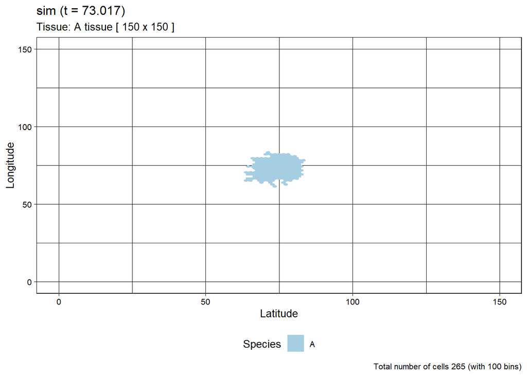

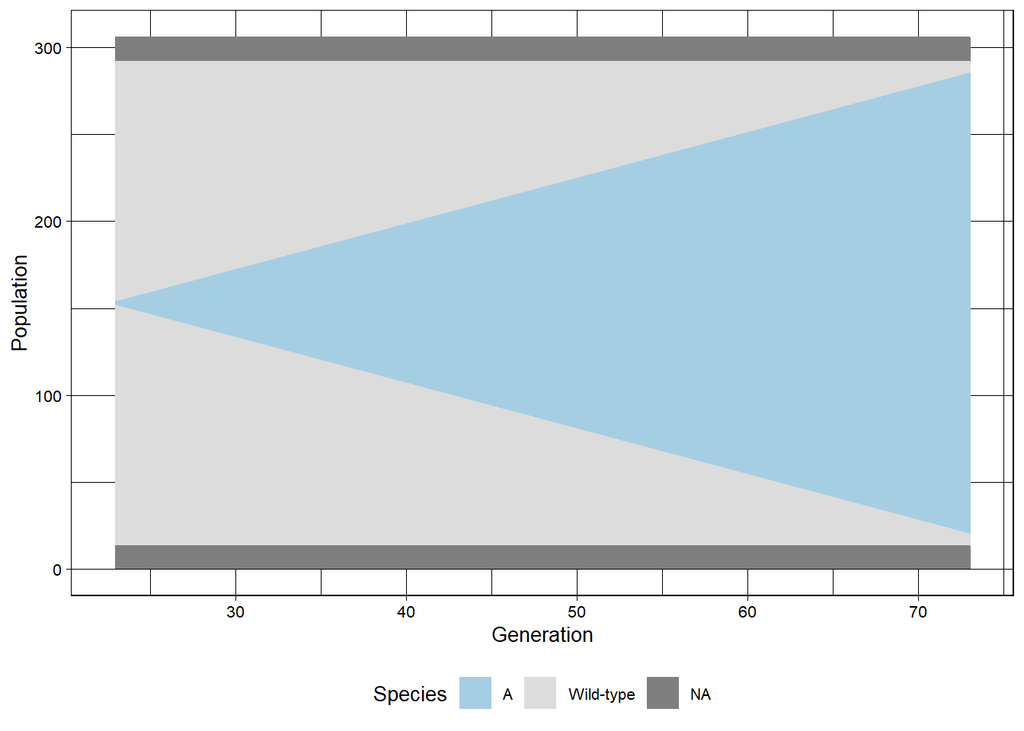

```r
# Parameter of the model
gr = 0.08
dr = 0
t=50

# Create simulation
sim <- new(Simulation, 'sim')
sim$update_tissue(150,150)

# Add the mutant A
sim$add_mutant('A', gr, dr)

# Place cell on the tissue
dim <- sim$get_tissue_size()
sim$place_cell('A', dim[1]/2, dim[2]/2)

# Run the simulation for other t time units
sim$run_up_to_time(sim$get_clock() + 1)
sim$run_up_to_time(sim$get_clock() + t)

# Summary statistic of the simulation (number of cells)
sum_stat_obs = c(sim$get_counts()$counts[1])
sum_stat_obs
```

Now we can obtain a summary statistic, in this case we will use the number of cells generated per 50 time units

### Model

In this model we assume we know:

- the death rate is 0
- for how many units of time to run the simulation

and we want to infer the growth rate, so $\gamma = gr$

```r
create_model <- function(t){
    model=function(x){
        if (x[1] > 0){
            tmp <- new(Simulation, 'tmp')
            tmp$add_mutant('A', x[1], 0)

            dim <- tmp$get_tissue_size()
            tmp$place_cell("A", dim[1]/2, dim[2]/2)

            tmp$run_up_to_time(tmp$get_clock() + 1)
            tmp$run_up_to_time(tmp$get_clock() + t)

            c(tmp$get_counts()$counts[1])
        } else {
            c(0)
        }
    }
    print("The model has been created")
    return(model)
}
```

The function takes as input the precisely known parameters and creates another function called **gr_model** which will be used by the ABC algorithm to compute the set of summary statistics $S(y_{i})$.

Once the **gr_model** has been created we can proceed with using the *ABC_rejection* algorithm.

### ABC rejection

This sampling scheme consists in drawing the model parameters in the prior distributions, in using these model parameter values to launch a simulation and in repeating this two-step procedure **nb_simul** times. At the end of the **nb_simul** simulations, the simulations closest to the target (or at a distance smaller than a tolerance threshold) in the space of the summary statistics are retained to form an approximate posterior distribution of the model parameters.

```r
# Create the gr_model
model = create_model(t)

# Let's assume that the parameter is in a uniform distribution [0,0.1]
prior = list(c("unif",0,0.1))

set.seed(1)
nb_simul=300
tr=0.1

ABC_rej <- ABC_rejection(
    model=model,
    prior=prior,
    nb_simul=nb_simul,
    summary_stat_target=sum_stat_obs,
    tol=tr)
```

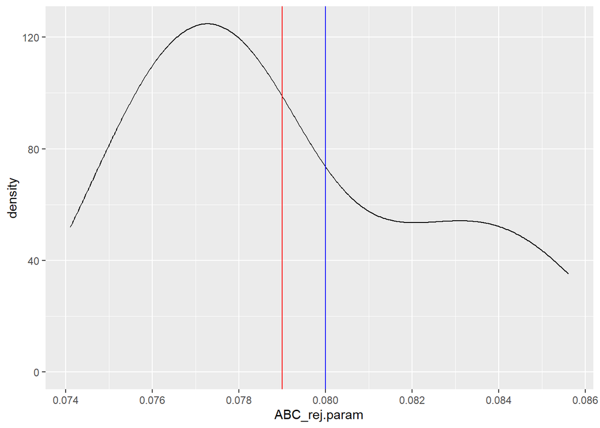

```
##     Estimated       True
## gr 0.07900331 0.08000000
```

Now let’s try to estimate $\gamma$ where the $dr \neq 0$ and see what happens

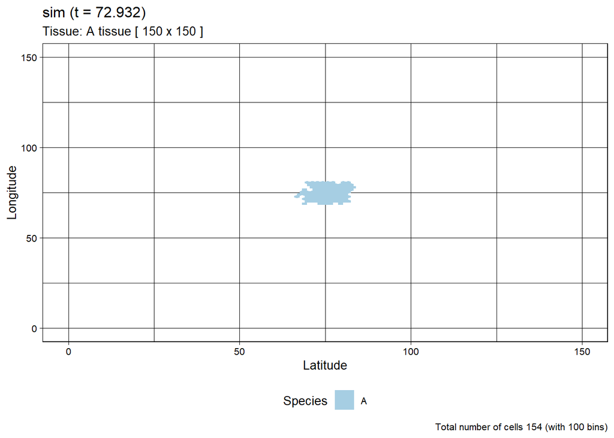

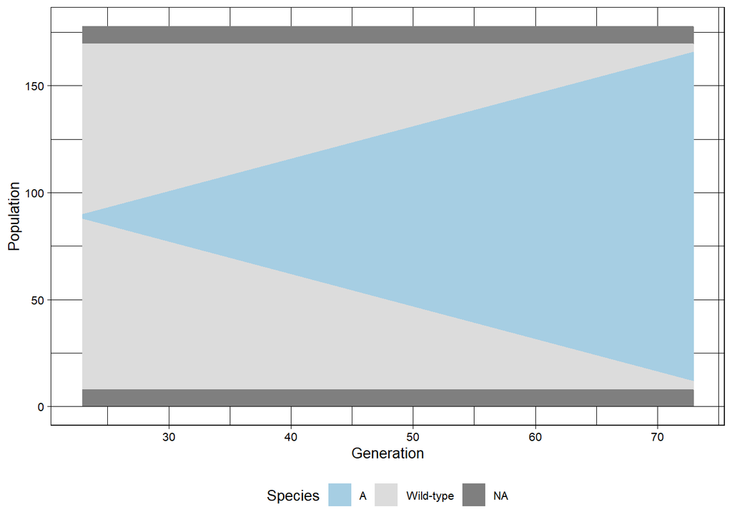

```r
# Parameter of the model
gr = 0.08
dr = 0.00135
t=50

# Create simulation
sim <- new(Simulation, 'sim')
sim$update_tissue(150,150)

# Add the mutant A
sim$add_mutant('A', gr, dr)

# Place cell on the tissue
dim <- sim$get_tissue_size()
sim$place_cell('A', dim[1]/2, dim[2]/2)

# Run the simulation for other t time units
sim$run_up_to_time(sim$get_clock() + 1)
sim$run_up_to_time(sim$get_clock() + t)

# Summary statistic of the simulation (number of cells)
sum_stat_obs = c(sim$get_counts()$counts[1])
sum_stat_obs
```

Now we can obtain a summary statistic, in this case we will use the number of cells generated per 50 time units

### Model

In this model we assume we know:

- for how many units of time to run the simulation

and we want to infer the growth rate, so $\gamma = gr - dr$

```r
create_model <- function(t){
    model=function(x){
        if (x[1] > 0 & x[2] > 0){
            tmp <- new(Simulation, 'tmp')
            tmp$add_mutant('A', x[1], x[2])

            dim <- tmp$get_tissue_size()
            tmp$place_cell("A", dim[1]/2, dim[2]/2)

            tmp$run_up_to_time(tmp$get_clock() + 1)
            tmp$run_up_to_time(tmp$get_clock() + t)

            c(tmp$get_counts()$counts[1])
        } else {
            c(0)
        }
    }
    print("The model has been created")
    return(model)
}
```

The function takes as input the precisely known parameters and creates another function called **gr_model** which will be used by the ABC algorithm to compute the set of summary statistics $S(y_{i})$.

Once the **gr_model** has been created we can proceed with using the *ABC_rejection* algorithm.

### ABC rejection

This sampling scheme consists in drawing the model parameters in the prior distributions, in using these model parameter values to launch a simulation and in repeating this two-step procedure **nb_simul** times. At the end of the **nb_simul** simulations, the simulations closest to the target (or at a distance smaller than a tolerance threshold) in the space of the summary statistics are retained to form an approximate posterior distribution of the model parameters.

```r
# Create the gr_model
model = create_model(t)

# Let's assume that the gr is in a uniform distribution [0,0.1] and
# dr in a unform [0,0.05]
prior = list(c("unif",0,0.1),
             c("unif",0,0.05))

set.seed(1)
nb_simul=300
tr=0.1

ABC_rej <- ABC_rejection(
    model=model,
    prior=prior,
    nb_simul=nb_simul,
    summary_stat_target=sum_stat_obs,
    tol=tr)
```

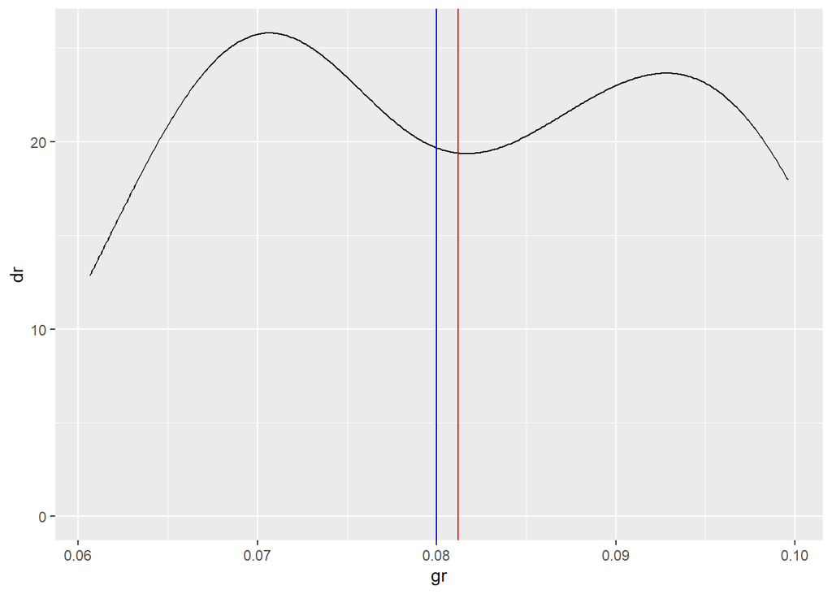

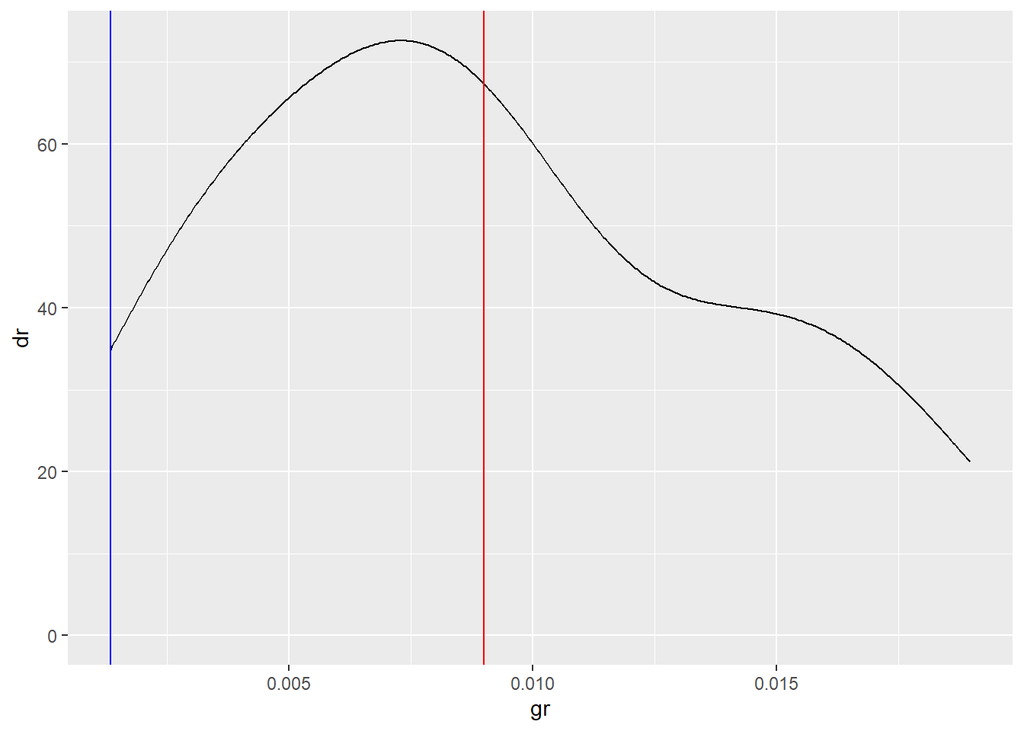

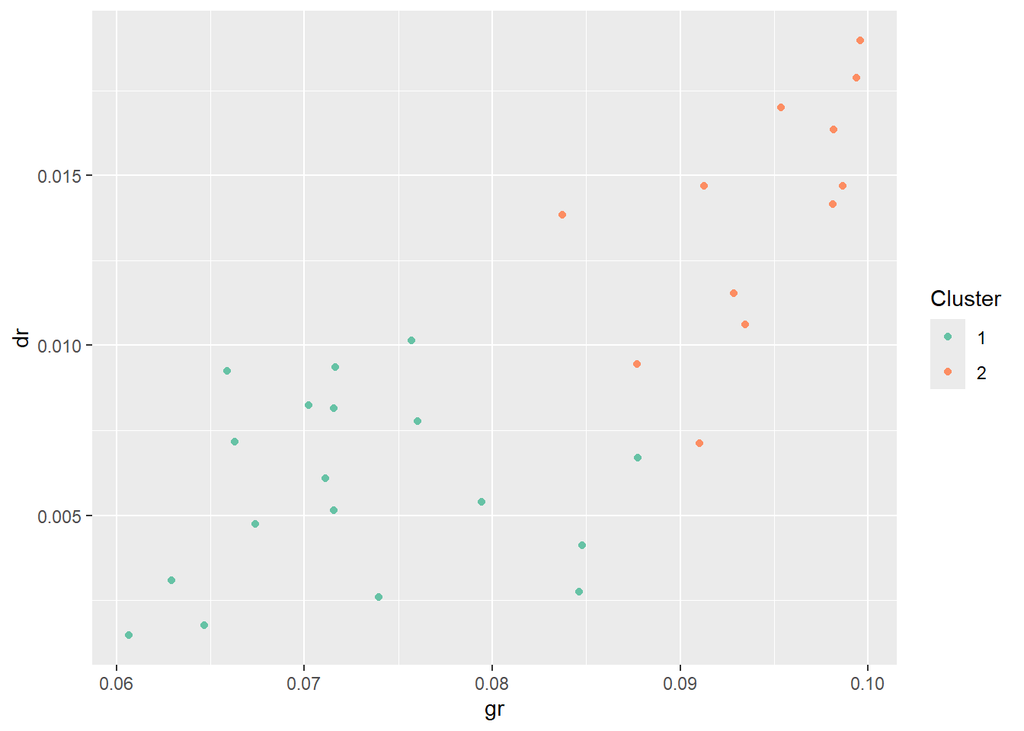

```
##     Estimated       True
## gr 0.08118548 0.08000000
```

### More examples

#### Infer growth rate of sub mutant

Pay attention to the statistics used in this example, to make a good inference of the parameter we use the number of $A$ cells and the number of $B$ cells, so a vector of summary statistics.

```r
# Parameter of the model
gr1 = 0.0568
dr1 = 0

gr2 = 0.0897
dr2 = 0

t=25

# Create simulation
sim <- new(Simulation, 'sim')

# Add the mutant A
sim$add_mutant('A', gr, dr)

# Place cell on the tissue
dim <- sim$get_tissue_size()
sim$place_cell("A", dim[1]/2, dim[2]/2)

# Run the simulation for other t time units
sim$run_up_to_time(sim$get_clock() + t)

# Add the mutant B
sim$add_mutant('B', gr2, dr2)

# Mutant injection
sim$mutate_progeny(sim$choose_cell_in('A'), 'B')

sim$run_up_to_time(sim$get_clock() + t)


# Summary statistic of the simulation (number of cells)
sum_stat_obs = c(sim$get_counts()$counts[1],
                 sim$get_counts()$counts[2])
sum_stat_obs
```

### Model

In this model we assume we know:

- the growth rate of the mutant $A$
- the death rate of both mutant
- for how many units of time to run the simulation

and we want to infer the growth rate of mutant $B$

```r
create_model <- function(gr1, dr1, dr2, t){
    model=function(x){
        if (x[1] > 0){
            tmp <- new(Simulation, 'tmp')
            tmp$add_mutant('A', gr1, dr1)

            dim <- tmp$get_tissue_size()
            tmp$place_cell("A", dim[1]/2, dim[2]/2)

            tmp$run_up_to_time(tmp$get_clock() + t)

            tmp$add_mutant('B', x[1], dr2)
            tmp$mutate_progeny(tmp$choose_cell_in('A'), 'B')
            tmp$run_up_to_time(tmp$get_clock() + t)

            c(tmp$get_counts()$counts[1],
              tmp$get_counts()$counts[2])
        } else {
            c(0,0)
        }
    }
    assign("sub_gr_model",model, envir = .GlobalEnv)
    print("The model has been created")
    return(invisible())
}
```

```r
# Create the sub_gr_model
create_model(gr1, dr1, dr2, t)

# Let's assume that the parameter is around a norm with mean 0.1 and var 0.08
prior = list(c("normal",0.1,0.08))

set.seed(1)
nb_simul=100
tr=0.05

ABC_rej <- ABC_rejection(
    model=sub_gr_model,
    prior=prior,
    nb_simul=nb_simul,
    summary_stat_target=sum_stat_obs,
    tol=tr)
```

```
##            [,1]
## [1,] 0.06174800
## [2,] 0.06680043
## [3,] 0.06845680
## [4,] 0.06453665
## [5,] 0.06212795
```

[output not shown]

#### Infer growth rate of one mutant and sub mutant

In this example we will use the relationship between $\frac{\#cell B}{\#cell A}$

```r
# Parameter of the model
gr1 = 0.0777
dr1 = 0

gr2 = 0.0987
dr2 = 0

t=25

# Create simulation
sim <- new(Simulation, 'sim')

# Add the mutant A
sim$add_mutant('A', gr, dr)

# Place cell on the tissue
dim <- sim$get_tissue_size()
sim$place_cell("A", dim[1]/2, dim[2]/2)

# Run the simulation for other t time units
sim$run_up_to_time(sim$get_clock() + t)

# Add the mutant B
sim$add_mutant('B', gr2, dr2)

# Mutant injection
sim$mutate_progeny(sim$choose_cell_in('A'), 'B')

sim$run_up_to_time(sim$get_clock() + t)


# Summary statistic of the simulation (number of cells)
sum_stat_obs = c(sim$get_counts()$counts[2]/sim$get_counts()$counts[1])
sum_stat_obs
```

### Model

```r
create_model <- function(dr1, dr2, t){
    model=function(x){
        if (x[1] > 0){
            tmp <- new(Simulation, 'tmp')
            tmp$add_mutant('A', x[1], dr1)

            dim <- tmp$get_tissue_size()
            tmp$place_cell("A", dim[1]/2, dim[2]/2)

            tmp$run_up_to_time(tmp$get_clock() + t)

            tmp$add_mutant('B', x[2], dr2)
            tmp$mutate_progeny(tmp$choose_cell_in('A'), 'B')
            tmp$run_up_to_time(tmp$get_clock() + t)

            c(tmp$get_counts()$counts[2]/tmp$get_counts()$counts[1])
        } else {
            c(0)
        }
    }
    assign("two_param_model",model, envir = .GlobalEnv)
    print("The model has been created")
    return(invisible())
}
```

```r
# Create the sub_gr_model
create_model(dr1, dr2, t)

# Let's assume that the parameter is around a norm with mean 0.1 and var 0.08
prior = list(c("normal",0.1,0.04), c("normal",0.12,0.04))

set.seed(1)
nb_simul=100
tr=0.05

ABC_rej <- ABC_rejection(
    model=two_param_model,
    prior=prior,
    nb_simul=nb_simul,
    summary_stat_target=sum_stat_obs,
    tol=tr)
```

```
##             [,1]       [,2]
## param 0.08422840 0.11762746
## param 0.07725325 0.11459286
## param 0.07457054 0.10153421
## param 0.09141682 0.11281774
## param 0.08279153 0.08295562
```

[output not shown]